# Evaluación 02 - Regresión Lineal Múltiple

EDU3826

Author

Dany Lopez (dxlopez@ul.cl) - José Luis Pérez (josel.perez@uc.cl)

Modified

May 23, 2025

# Objetivo

- Aplicar modelos de regresión lineal a un problema educativo.
- Reportar estadísticos descriptivos.
- Analizar la asociación entre variables.

# Instrucciones de entrega

- Este informe forma parte del segundo de tres informes que deben entregarse como evaluación formal del curso.
- Este informe se sitúa dentro de un contexto educativo que se explica al principio. En base a este contexto, se presentan luego una seria de preguntas que deben ser contestadas.
- Como puede observar, este informe está diseñado para trabajarlo en *R*. Sin embargo, también puede realizar los análisis de datos en BlueSky Statistics.
- Este informe se debe realizar en grupo de tres personas y se debe contestar completamente a cada pregunta planteada.
- El formato de entrega debe ser en *word* y en *pdf*, y debe incluir sus nombres y correos electrónicos. Si lo desea, también puede usar *LaTeX*, *Rmarkdown* o *Quarto* si así lo prefiere.
- La entrega deberá realizar en el buzón de tareas de *canvas* antes de la fecha acordada.
- Perte de este taller se trabajará en clases, y el resto deberá resolverlo por su cuenta. Sin embargo, estará disponible el foro de Canvas para que pueda plantear dudas en caso de que las tenga.
- Para realizar este taller, les sugerimos que se apoyen en los siguientes documentos:

[**link 1**](https://danynash.com/lessons/02-LinearRegression1V/) para mayores detalles sobre interpretación y ajuste de modelos de regresión lineal.

[**link 2**](https://danynash.com/lessons/03-MultipleLinearRegression/) para mayores detalles sobre interpretación de modelos de regresión lineal múltiple.

Mucho éxito 😁

# Contexto Educativo

La fuente de datos que usaremos se sustenta en el modelo 3P de Biggs (2001), Presagio, Proceso y Producto (de la tradición de investigación sobre el aprendizaje de los estudiantes). El modelo 3P es útil para tener un modelo conceptual de referencia que permite estructurar las distintas variables que condicionan el rendimiento académico en educación superior. A continuación podemos ver cómo el modelo 3P se relaciona con variables claves según su naturaleza.

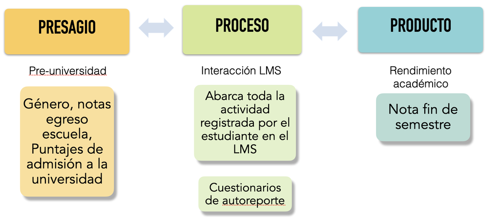

```r
#knitr::include_graphics('./Images/Informe.pdf')
knitr::include_graphics('./Images/3P.png')
```

## Variables de interés

Para los efectos de este taller, vamos a centrar el foco en las variables descritas a continuación:

- Como variable *producto* vamos a considerar las `notas promedio` finales del segundo semestre de estudiantes de la carrera de Ingeniería de una universidad pública.
- Como variable *Presagio* vamos a considerar el `género` del estudiante, con 1 indicando Femenino y 0 indicando Masculino.
- Como variable *Proceso* vamos a considerar dos tipos de datos: (1) Reporte de estudiantes sobre las aproximaciones al aprendizaje que adoptan los estudiantes. Para este caso, se cuenta con dos tipos de variables, `Aprendizaje superficial` y `Aprendizaje profundo` que provienen de un promedio a partir de 5 ítems. (2) Registro de la actividad en línea de los estudiantes en sistemas de gestión del aprendizaje (LMS). Aqui se considera una variable que refiere a la `candiad de veces que un estudiante accedió a contenido del curso`.

A continuación tiene una descripción completa de todas las variables contenidas en la base de datos.

| Nombre Variable | Tipo de variable | Tipo de dato | Origen variable | Descripcion |
| --- | --- | --- | --- | --- |
| ID_student | ID | Identificador | Generada internamente | Identificador único del estudiante |
| genero | sociodemográfica | Categorica | Declarada por estudiante | Género del estudiante: F indica Femenino y M indica Masculino |
| nota_sem | Rendimiento académico | Continua | Proporcionada por institución educativa | Promedio ponderado final de todoslos ramos en un semestre respectivo |
| Aprendizaje_superficial_prom | Experiencia de aprendizaje | Continua | Derivada del los puntajes de un cuestionario | Puntuación media en la escala de aproximación al aprendizaje superficial medida por medio de un cuestionario a través de una escala Likert de 5 niveles: 1 indica "Totalmente en desacuerdo", 2 indica "… |
| Aprendizaje_profundo_prom | Experiencia de aprendizaje | Continua | Derivada del los puntajes de un cuestionario | Puntuación media en la escala de Aproximación al Aprendizaje Profundo medida por medio de un cuestionario a través de una escala Likert de 5 niveles: 1 indica "Totalmente en desacuerdo", 2 indica "En … |
| acceso_contenido_online | Interacción plataformas digitales | Discreta | Generada a partir de datos insitucionales a partir de registro de uso de recursos digitales | Frecuencia total semestral de acceso a contenido academico en plataforma online de gestión del aprendizaje proporcionada por la institución |

## Objetivo de estudio

Queremos explorar cómo se relacionan el rendimiento académico de estudiantes de primer año de universidad con variables sociodemográficas, cuestionarios de auto reporte sobre aproximaciones al aprendizaje y con la actividad en línea en sistemas de gestión del aprendizaje (LMS).

## Etapa 0: Elementos previos

Para aquellas personas que trabajarán en R, deberán cargar algunas librerías fundamentales para procesar inicialmente nuestros datos, como la librería `readxl`,`dplyr`, `tidyr` y `ggplot2`. Note que **Para que los códigos incluídos como guías de este informe funcionen es necesario que las librerías recomendadas sean instaladas primero, una vez que se instalan no se deben volver a instalar.**

Esta librería, la podemos llamar e instalar empleando las siguientes línea de código:

```r
#--------------------------------------
# instalar librerias
#--------------------------------------

#install.packages('readxl') # borrar el símbolo # para ejecutar código
#install.packages('dplyr') # borrar el símbolo # para ejecutar código
#install.packages('tidyr') # borrar el símbolo # para ejecutar código
#install.packages('ggplot2') # borrar el símbolo # para ejecutar código
#install.packages('texreg') # borrar el símbolo # para ejecutar código

#------------------------------------------------------------------------------
#  cargar librarias
#------------------------------------------------------------------------------

library(readxl)
library(dplyr)
library(tidyr)
library(ggplot2)
library(texreg)

#------------------------------------------------------------------------------
#  Opcioes especiales
#------------------------------------------------------------------------------

# Evita la notacion cientifica
options(scipen=999)
```

## Etapa 1: Lectura de de datos

- Vamos a abrir los datos que se encuentran en formato *xlsx*. Vamos a emplear a la libreria `readxl` para que R pueda leer estos datos.

**Nota**

En general en `R` tendremos que usar diferentes funciones y librerias para abrir archivos en diferentes formatos.

```r
#---------------------------------------------------------------
# Cargando datos
#---------------------------------------------------------------

# Dato
data <- readxl::read_excel("DDBB/02BaseDatosLMS.xlsx",
                         sheet='Base de Datos', na=c(""), col_names = TRUE)
```

La base de datos cargada se muestra a continuación para los primeros 10 registros.

| ID_student | genero | carrera | Ap_sup_mean | Ap_prof_mean | nota_sem | acceso_contenido_online |
| --- | --- | --- | --- | --- | --- | --- |
| student_5000 | 1 | Ingenieria | 3.00 | 3.50 | 5.550000 | 393 |
| student_5001 | 1 | Ingenieria | 3.00 | 3.00 | 5.400000 | 305 |
| student_5002 | 0 | Ingenieria | 4.25 | 3.25 | 5.075000 | 131 |
| student_5003 | 1 | Ingenieria | 3.50 | 4.00 | 5.600000 | 270 |
| student_5004 | 0 | Ingenieria | 3.75 | 4.00 | 5.800000 | 288 |
| student_5005 | 0 | Ingenieria | 4.50 | 4.25 | 4.850000 | 261 |
| student_5006 | 0 | Ingenieria | 2.25 | 4.75 | 4.200000 | 118 |
| student_5007 | 1 | Ingenieria | 3.75 | 3.50 | 5.366667 | 492 |
| student_5008 | 1 | Ingenieria | 4.50 | 3.50 | 4.800000 | 135 |
| student_5009 | 1 | Ingenieria | 2.50 | 3.75 | 4.833334 | 305 |

# Responda las siguientes preguntas

## Sección 1: Descriptivos

### Pregunta 1.1

Antes de ajustar modelos a los datos, vamos a realizar estadística descriptiva. Realice una tabla descriptiva de los datos y describa sus tendencias.

### Pregunta 1.2

Realice tres gráficos de dispersión que muestre visualmente la relación entre las `notas del semestre` con las variables `Aprendizaje superficial`, `Aprendizaje profundo` y con `acceso a contenido online`. Describa las relaciones que observa. A continuación se muestra un ejemplo para las variables `notas del semestre` y `Aprendizaje superficial`:

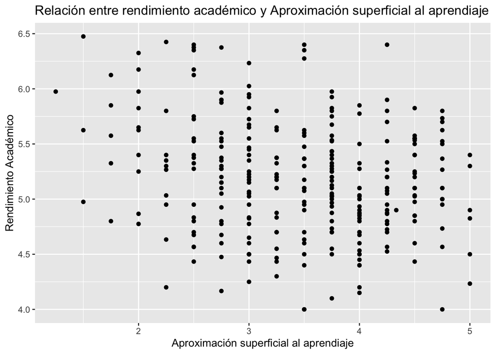

```r
library(ggplot2)
# Crear un gráfico de dispersión con la línea de regresión
ggplot(data, aes(x = Ap_sup_mean, y = nota_sem)) +
  geom_point() +
  labs(title = "Relación entre rendimiento académico y Aproximación superficial al aprendiaje",
       x = "Aproximación superficial al aprendiaje",
       y = "Rendimiento Académico")
```

### Pregunta 1.3

Realice un gráfico de caja y bigotes (o boxplot) considerando `notas del semestre` en el eje vertical y el `género` en el eje horizontal. Luego, describa la relación que observa entre estas dos variables. A continuación se muestra el código para realizar este gráfico:

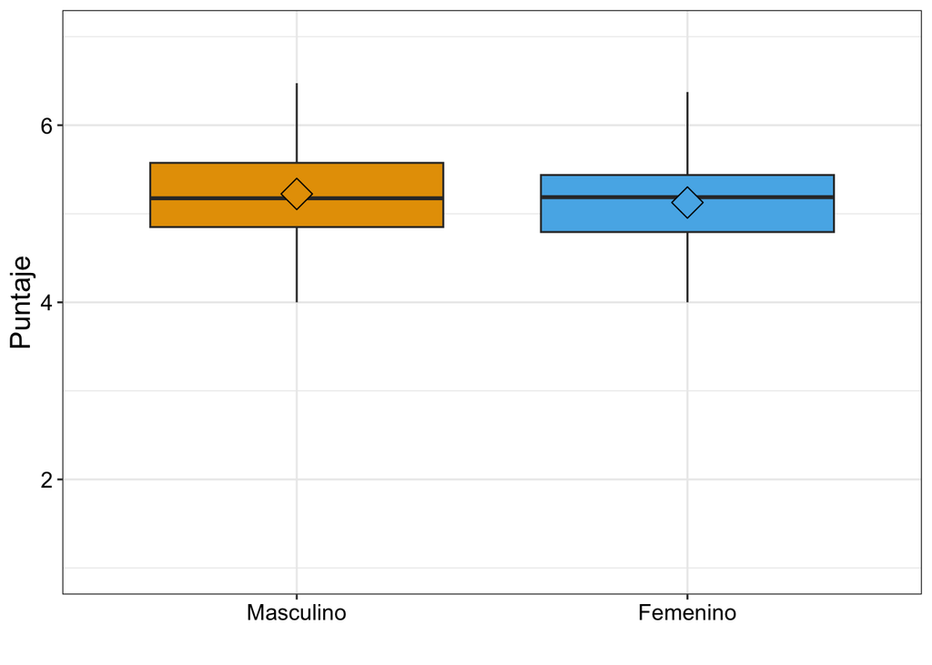

```r
library(ggplot2)

p<-ggplot(data, aes(x=as.factor(genero), y=nota_sem, fill=as.factor(genero))) +
  geom_boxplot()+
  theme_bw() +
  theme(
    text = element_text(size = 15),
    axis.text.x = element_text(color = "black",angle = 0, hjust = 0.5),
    #  text = element_text(size = 15),
    axis.text.y = element_text(color = "black",angle = 0, hjust = 0.5),
    legend.position = "none"
  ) +
  labs( x = "",
        y = "Puntaje") +
  ylim(c(1,7))

p <- p + scale_fill_manual(values= c( "#E69F00", "#56B4E9"))
p <- p + stat_summary(fun=mean, geom="point", shape=23, size=6)
p + scale_x_discrete(labels = c("Masculino","Femenino"))
```

### Pregunta Formativa 1.4

Realice análisis de correlaciones entre las variables de interés. Reporte sus resultados en una matriz de correlaciones y verbalmente. Puede guíarse en la sección `Análisis de correlación` del documento ubicado en [**link 2**](https://cursos.canvas.uc.cl/courses/87358/modules/items/2560455).

**Note que esta pregunta será evaluada de manera formativa.**

## Sección 2: Ajuste de modelos de regresión lineal

Ahora ajustaremos los siguientes modelos lineales para abordar por completo el propósito planteado. Para ello, considere los siguientes modelos:

- **Modelo 1:** $\text{Nota}_{sem} = \beta_0 + \beta_1 \text{genero} +\varepsilon$
- **Modelo 2:** $\text{Nota}_{sem} = \beta_0 + \beta_1 \text{Aprendizaje}_{sup} + \beta_2 \text{Aprendizaje}_{prof} +\varepsilon$
- **Modelo 3:** $\text{Nota}_{sem} = \beta_0 + \beta_1 \text{Aprendizaje}_{sup} + \beta_2 \text{Aprendizaje}_{prof} + \beta_3 \text{Contenido}_{online}+\varepsilon$
- **Modelo 4:** $\text{Nota}_{sem} = \beta_0 + \beta_1 \text{genero} +\beta_2 \text{Aprendizaje}_{sup} + \beta_3 \text{Aprendizaje}_{prof} + \beta_4 \text{Contenido}_{online}+\varepsilon$

### Pregunta 2.1:

Ajuste los cuatro modelos anteriores. Reporte estos resultados en una tabla. Para el reporte de la tabla, utilice el formato APA [**ver aquí**](https://apastyle.apa.org/style-grammar-guidelines/tables-figures/sample-tables#regression)

Utilice el siguiente código para ajustar los modelos

```r
#-----------------------
# Ajuste modelos
#----------------------

m1 <-  lm(nota_sem ~ genero, data = data)
m2 <-  lm(nota_sem ~ Ap_sup_mean + Ap_prof_mean, data = data)
m3 <-  lm(nota_sem ~ Ap_sup_mean + Ap_prof_mean + acceso_contenido_online, data = data)
m4 <-  lm(nota_sem ~ genero+ Ap_sup_mean + Ap_prof_mean + acceso_contenido_online, data = data)
```

Recuerde que si desea ver el resultadodel `modelo 1`, puede utilizar la función `summary()`. Proceder de manera análoga para los demás modelos.

```r
# Resumen del modelo
summary(m1)
```

```
Call:
lm(formula = nota_sem ~ genero, data = data)

Residuals:
     Min       1Q   Median       3Q      Max
-1.22399 -0.35187 -0.02399  0.34812  1.25101

Coefficients:
            Estimate Std. Error t value Pr(>|t|)
(Intercept)  5.22399    0.03888 134.378   <2e-16 ***
genero      -0.09711    0.06075  -1.599    0.111
---
Signif. codes:  0 '***' 0.001 '**' 0.01 '*' 0.05 '.' 0.1 ' ' 1

Residual standard error: 0.5113 on 291 degrees of freedom
Multiple R-squared:  0.008706,  Adjusted R-squared:  0.0053
F-statistic: 2.556 on 1 and 291 DF,  p-value: 0.111
```

Si desea un resultado integrado, puede utilizar el siguiente código

```r
#Resumen integrado

library(sjPlot)
library(sjmisc)
library(sjlabelled)

tab_model(m1,m2,m3,m4,
          auto.label = FALSE,
          show.ci = FALSE,
          pred.labels = c("Intercepto",
                          "Género",
                          "Aprendizaje superficial",
                          "Aprendizaje profundo",
                          "Acceso a contenido online"),
          dv.labels = c("M01",
                        "M02",
                        "M03",
                        "M04"),
          p.style = "stars",
          digits = 3
)
```

|  | M01 | M02 | M03 | M04 |
| --- | --- | --- | --- | --- |
| Predictors | Estimates | Estimates | Estimates | Estimates |
| Intercepto | 5.224 *** | 5.186 *** | 4.926 *** | 4.945 *** |
| Género | -0.097 |  |  | -0.052 |
| Aprendizaje superficial |  | -0.112 ** | -0.103 ** | -0.098 ** |
| Aprendizaje profundo |  | 0.105 * | 0.106 * | 0.101 * |
| Acceso a contenido online |  |  | 0.001 *** | 0.001 *** |
| Observations | 293 | 293 | 293 | 293 |
| R<sup>2</sup> / R<sup>2</sup> adjusted | 0.009 / 0.005 | 0.068 / 0.062 | 0.127 / 0.118 | 0.130 / 0.117 |
| * p<0.05 ** p<0.01 *** p<0.001 |  |  |  |  |

**Nota**

- Note que la tabla anterior es la misma tabla que se espera que usted obtenga. Es importante que pueda reproducir estos resultados por su cuenta, ya sea usando R o BlueSky Statistics.

### Pregunta 2.2:

**Nota**

- Recuerde considerar el $R_{adj}$ cuando se tiene un modelo de regresión lineal múltiple.

### Pregunta 2.3:

Analice la significancia estadística de cada modelo y de los parámetros estimados para cada covariable ¿Qué puede decir el líneas generales? Luego de que haya analizado la significancia estadística, interprete los siguientes párametros estimados:

- $\hat \beta_1$ del `modelo 1`
- $\hat \beta_1$ y $\hat \beta_2$ del `modelo 2`
- $\hat \beta_3$ del `modelo 3`
- $\hat \beta_1$ y $\hat \beta_3$ del `modelo 4`.

### Pregunta 2.4:

Resuma la varianza explicada por cada modelo en una tabla y a partir de estos resultados explique cuál modelo considera más apropiado para explicar la variable dependiente considerando tanto la proporción de varianza explicada como la complejidad del modelo. Justifique su respuesta.

Back to top